# Lab 08 - Text Mining/NLP

# Learning goals

- Use `unnest_tokens()` and `unnest_ngrams()` to extract tokens and ngrams from text
- Use dplyr and ggplot2 to analyze and visualize text data
- Try a theme model using `topicmodels`

# Lab description

For this lab we will be working with the medical record transcriptions from https://www.mtsamples.com/ available at https://github.com/JSC370/JSC370-2025/tree/main/data/medical_transcriptions.

# Deliverables

1. Questions 1-7 answered, knit to pdf or html output uploaded to Quercus.
2. Render the Rmarkdown document using `github_document` and add it to your github site. Add link to github site in your html.

### Setup packages

You should load in `tidyverse`, (or `data.table`), `tidytext`, `wordcloud2`, `tm`, and `topicmodels`.

## Read in the Medical Transcriptions

Loading in reference transcription samples from https://www.mtsamples.com/

```
## # A tibble: 6 × 3
##   description                                    medical_specialty transcription
##   <chr>                                          <chr>             <chr>
## 1 A 23-year-old white female presents with comp… Allergy / Immuno… "SUBJECTIVE:…
## 2 Consult for laparoscopic gastric bypass.       Bariatrics        "PAST MEDICA…
## 3 Consult for laparoscopic gastric bypass.       Bariatrics        "HISTORY OF …
## 4 2-D M-Mode. Doppler.                           Cardiovascular /… "2-D M-MODE:…
## 5 2-D Echocardiogram                             Cardiovascular /… "1.  The lef…
## 6 Morbid obesity.  Laparoscopic antecolic anteg… Bariatrics        "PREOPERATIV…
```

## Question 1: What specialties do we have?

We can use `count()` from `dplyr` to figure out how many different medical specialties are in the data. Are these categories related? overlapping? evenly distributed? Make a bar plot.

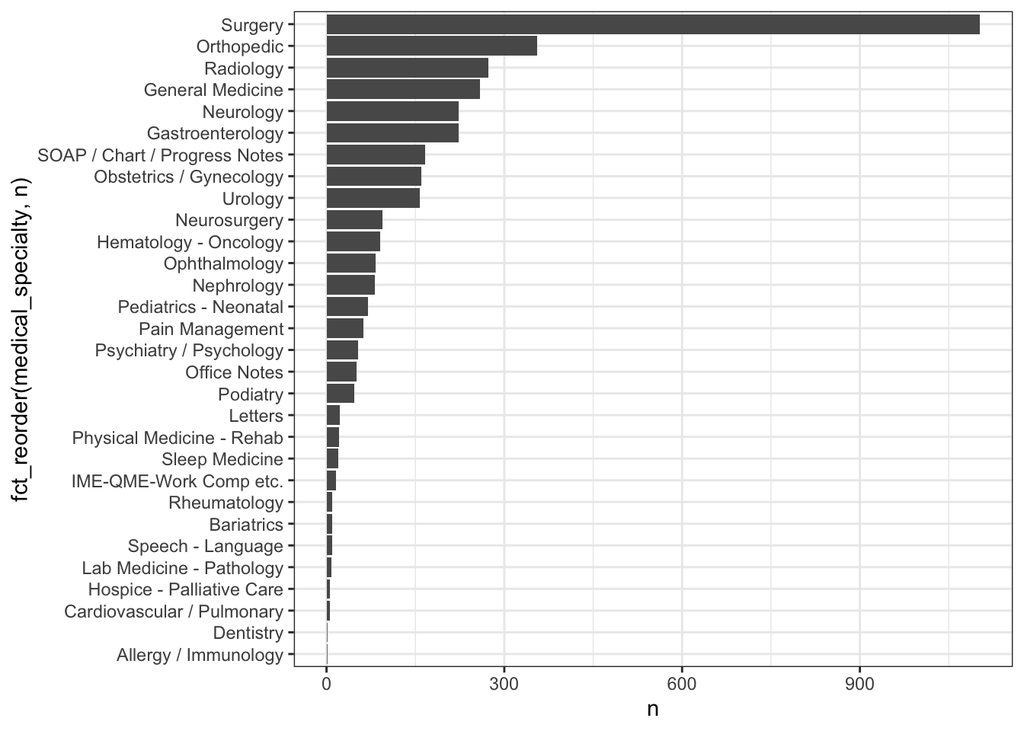

There are 30 different medical specialties, with the data being heavily skewed in favor of the surgery category. Categories are independent and little overlap is observed.

## Question 2: Tokenize

- Tokenize the the words in the `transcription` column
- Count the number of times each token appears
- Visualize the top 20 most frequent words with a bar plot
- Create a word cloud of the top 20 most frequent words

### Explain what we see from this result. Does it makes sense? What insights (if any) do we get?

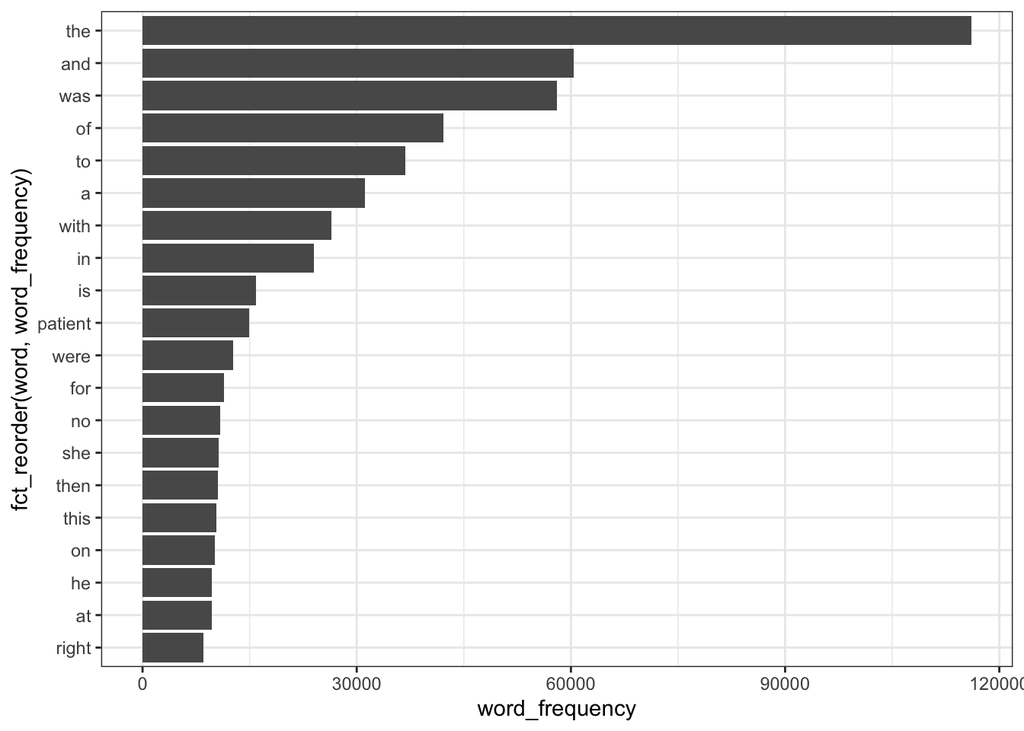

[interactive chart not shown]

From this result, the most common words are stopwords i.e. “the”, “and”, “was” … etc. This makes snese, and we don’t get a lot of meaningful insights. The word patient does come up quite often, indicating this is medical related data.

## Question 3: Stopwords

- Redo Question 2 but remove stopwords
- Check `stopwords()` library and `stop_words` in `tidytext`
- Use regex to remove numbers as well
- Try customizing your stopwords list to include 3-4 additional words that do not appear informative

### What do we see when you remove stopwords and then when you filter further? Does it give us a better idea of what the text is about?

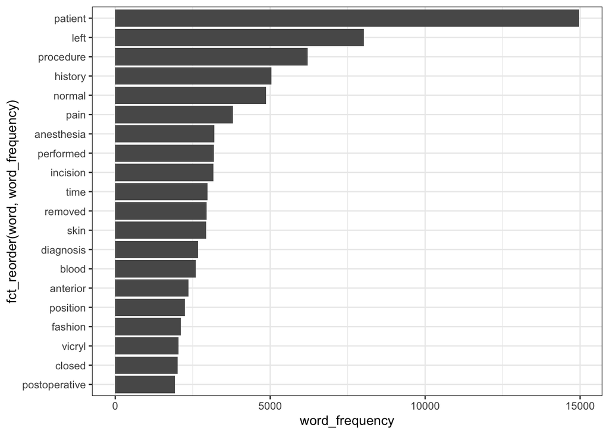

[interactive chart not shown]

Instead of prepositions, we see nouns, and verbs. For example, blood, skin, incision, provide better context of what topics the text is referring to.

## Question 4: ngrams

Repeat question 2, but this time tokenize into bi-grams. How does the result change if you look at tri-grams? Note we need to remove stopwords a little differently. You don’t need to recreate the wordclouds.

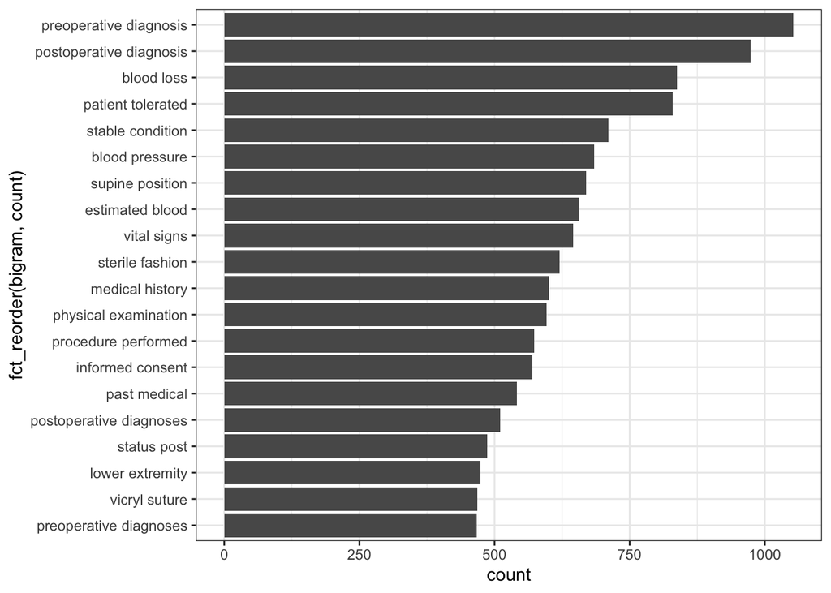

Note: tutorial said to not compute tri-grams. In the bi-grams, the frequency counts are reduced and each bigram is more informative than singular words. Shows that medical terminology usually comes in phrases rather than single words.

## Question 5: Examining words

Using the results from the bigram, pick a word and count the words that appear before and after it, and create a plot of the top 20.

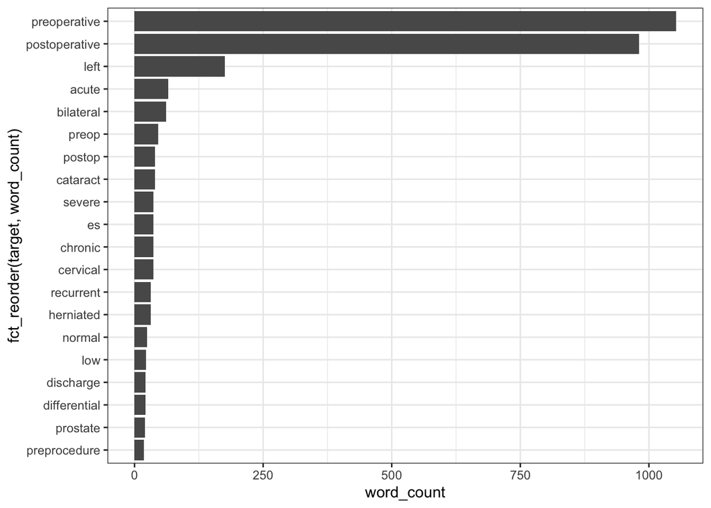

Word of choice: diagnosis.

## Question 6: Words by Specialties

Which words are most used in each of the specialties? You can use `group_by()` and `top_n()` from `dplyr` to have the calculations be done within each specialty. Remember to remove stopwords. How about the 5 most used words?

```
## # A tibble: 150 × 3
## # Groups:   medical_specialty [30]
##    medical_specialty    word         word_frequency
##    <chr>                <chr>                 <int>
##  1 Allergy / Immunology allergies                 4
##  2 Allergy / Immunology allegra                   3
##  3 Allergy / Immunology prescription              3
##  4 Allergy / Immunology sprays                    3
##  5 Allergy / Immunology erythematous              2
##  6 Bariatrics           patient                  29
##  7 Bariatrics           history                  21
##  8 Bariatrics           abdomen                  20
##  9 Bariatrics           procedure                18
## 10 Bariatrics           weight                   15
## # ℹ 140 more rows
```

```
## # A tibble: 95,131 × 3
## # Groups:   medical_specialty [30]
##    medical_specialty word       word_frequency
##    <chr>             <chr>               <int>
##  1 Surgery           patient              4855
##  2 Surgery           left                 3263
##  3 Surgery           procedure            3243
##  4 Orthopedic        patient              1711
##  5 Surgery           anesthesia           1687
##  6 Surgery           incision             1641
##  7 Surgery           removed              1574
##  8 Surgery           performed            1469
##  9 General Medicine  patient              1356
## 10 Surgery           skin                 1257
## # ℹ 95,121 more rows
```

The Allergy/Immunology specialty has top 5 words of allergies, sprays, prescription compared to Dentistry which has words like tooth, and removed. This makes sense. The top 5 most used words are patient, left, procedure, anesthesia, incision.

## Question 7: Topic Models

See if there are any themes in the data by using a topic model (LDA).

- you first need to create a document term matrix
- then you can try the LDA function in `topicmodels`. Try different k values.
- create a facet plot of the results from the LDA (see code from lecture)

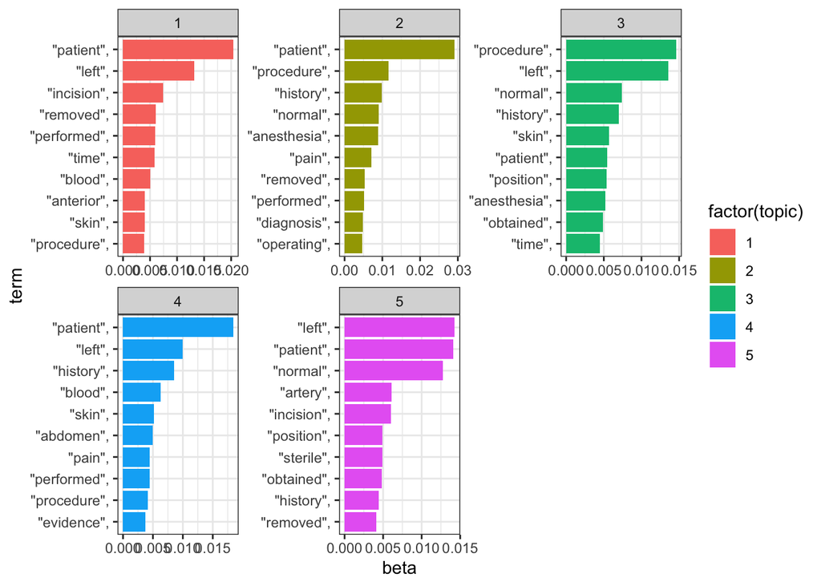

Sorting the words into categories we can observe “themes”. While many of the topics share similar words we can differentiate via others like abdomen in topic 4 and artery in topic 5. This gives evidence for procedures on different parts of the body.